# Aula 6A - Econometria de Séries Temporais

Autor

João Ricardo F. de Lima

Data de Publicação

15 de abril de 2025

# Metodologia de Box-Jenkins

Nos anos 70, Box e Jenkins utilizam da análise de “correlogramas” para identificar se uma série era I(0) ou não e para identificar as ordens “p” e “q” do modelo. Posteriormente, foram definidos testes estatísticos com tal finalidade, denominados de testes de raiz unitária, já vistos. Segundo a metodologia de Box-Jenkins, a análise de séries temporais tem por objetivo principal a realização de previsões.

Esta metodologia permite fazer previsões com base nos valores contemporâneos e passados explorando a correlação temporal entre os valores realizados pela série. O primeiro passo da metodologia é a *Identificação*. Isto significa descobrir qual dos possíveis modelos ARIMA descreve o comportamento da série. Filosofia: “Deixem os dados falarem por si mesmos”. Em outras palavras, é identificar os valores de “p”, “d” e “q”. Isto não pode ser feito apenas com a observação visual da série.

O primeiro passo na identificação é avaliar se a série é estacionária. Se não for, a série deve ser diferenciada “d” vezes até se tornar estacionária. Sendo a série original ou diferenciada, estacionária, o próximo passo é determinar se é gerada por um termo AR(p), MA(q) ou ARMA(p,q), além dos próprios valores de “p” e “q”.

De forma resumida e simplificada, o comportamento da FAC e FACp pode ser dado por:

Tabela 1: Comportamento da FAC e FACp:

| Processo | FAC | FACP |
| --- | --- | --- |
| AR(p) | Declinante | Truncada k=p |
| MA(q) | Truncada k=p | Declinante |
| ARMA(p,q) | Declinante | Declinante |

A **identificação** é a mais difícil das etapas da metodologia de Box e Jenkins. Normalmente mais de um modelo é escolhido para testar se é o gerador da série. Uma possibilidade é escolher o modelo com base nos critérios de Akaike (AIC) e Schwarz (BIC).

A segunda etapa é a **estimação** do modelo, sempre considerando o princípio da parcimônia.

A terceira etapa é a **verificação**: verificar se o modelo é adequado. A forma mais comum é a análise dos resíduos. Na análise dos resíduos deve-se verificar se o comportamento é de um ruído branco. Para isto, pode-se fazer um correlograma dos resíduos.

A quarta etapa é a **previsão**.

# Análise no Python

## Baixar e fazer gráfico da série

```python
from bcb import sgs
import pandas as pd
import numpy as np
import statsmodels.api as sm
import statsmodels.tsa.api as tsa
from statsmodels.graphics.tsaplots import plot_acf, plot_pacf
from statsmodels.stats.diagnostic import acorr_ljungbox
from statsmodels.stats.stattools import jarque_bera
from statsmodels.tsa.statespace.sarimax import SARIMAX
from statsmodels.tsa.arima.model import ARIMA
import matplotlib.pyplot as plt
from plotnine import *
import plotnine as p9
import seaborn as sns
from pmdarima import auto_arima
from arch.unitroot import DFGLS
import scipy.stats as stats
from sklearn.metrics import mean_absolute_error, mean_squared_error, mean_absolute_percentage_error
```

```
        Date  cambio
0 2004-01-01  2.8510
1 2004-02-01  2.9295
2 2004-03-01  2.9047
3 2004-04-01  2.9052
4 2004-05-01  3.0996
```

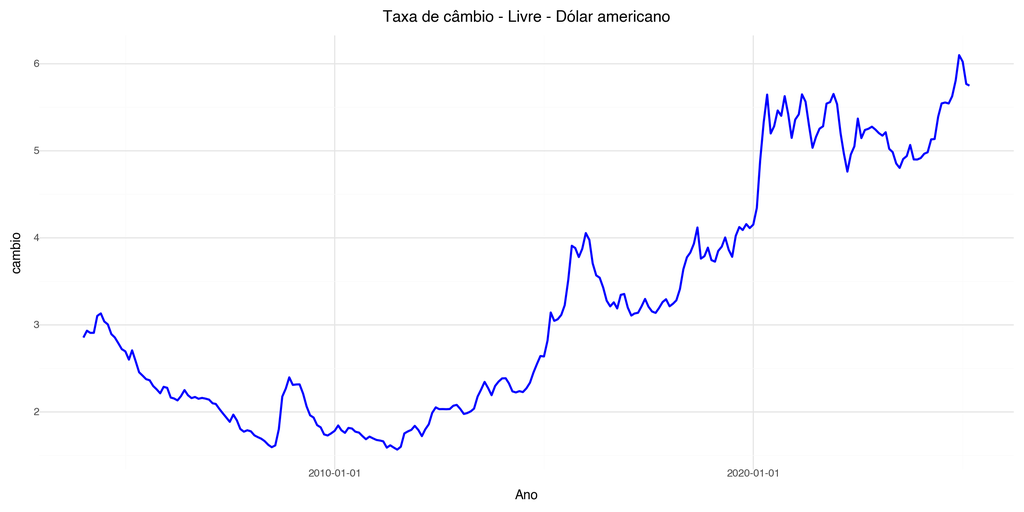

```python
# Define a série com dicionário, mesmo que seja uma só
series = {
    'cambio': 3697
}

# Baixar a série do IBC-BR
cambio = sgs.get(series, start='2004-01-01')

# Redefinir índice para obter 'date' como uma coluna
cambio = cambio.reset_index()

# Exibir as primeiras linhas para conferir
print(cambio.head())

# Transformar a coluna 'Date' para datetime, se necessário
cambio['Date'] = pd.to_datetime(cambio['Date'])

# Plot com plotnine
plot = (
    p9.ggplot(cambio, p9.aes(x='Date', y='cambio')) +
    p9.geom_line(color='blue', size=1) +
    p9.labs(title='Taxa de câmbio - Livre - Dólar americano', x='Ano', y='cambio') +
    p9.theme_minimal() +
    p9.theme(
      figure_size=(12, 6)
    )

)

plot.show()
```

### Gráfico, FAC e FACp

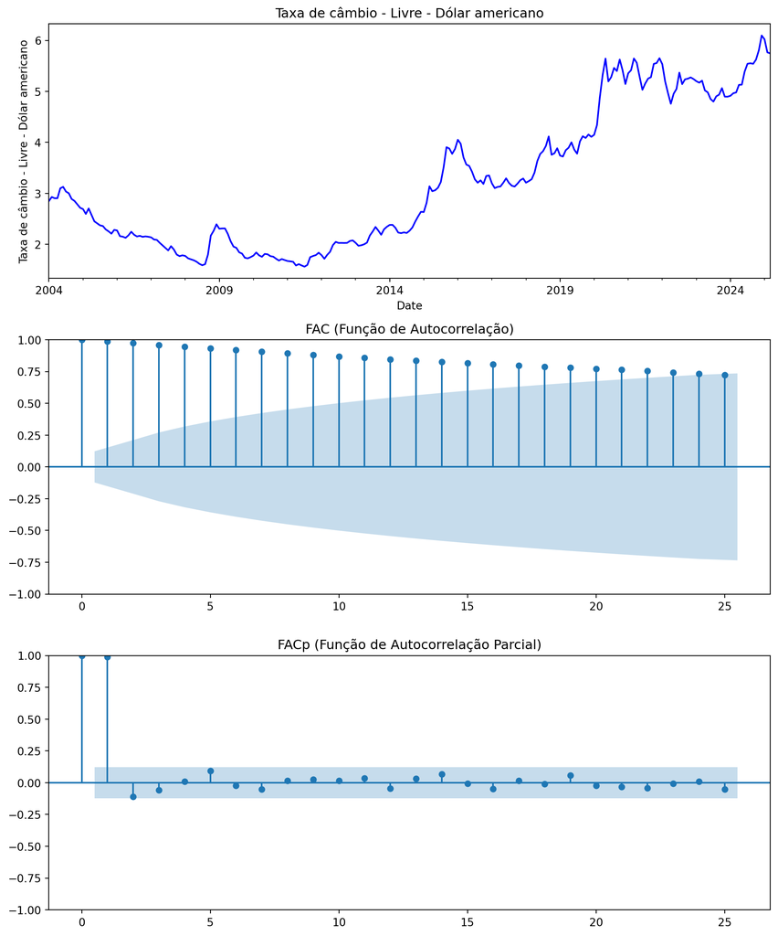

```python
#from statsmodels.graphics.tsaplots import plot_acf, plot_pacf

cambio = cambio.dropna()

# Converte a coluna 'Date' para datetime and configura como index
cambio['Date'] = pd.to_datetime(cambio['Date'])
cambio.set_index('Date', inplace=True)

# Plota cambio, FAC, e FACpa
fig, axes = plt.subplots(3, 1, figsize=(10, 12))

# Plota cambio
cambio['cambio'].plot(ax=axes[0], title='Taxa de câmbio - Livre - Dólar americano', color='blue')
axes[0].set_ylabel('Taxa de câmbio - Livre - Dólar americano')

# Plota FAC
plot_acf(cambio['cambio'], ax=axes[1], title='FAC (Função de Autocorrelação)')

# Plota FACp
plot_pacf(cambio['cambio'], ax=axes[2], title='FACp (Função de Autocorrelação Parcial)', method='ywm')

plt.tight_layout()
plt.show()
```

### Teste de Raiz Unitária DF-GLS

```python
# Executa o teste DF-GLS com seleção automática de defasagens
dfgls_test = DFGLS(cambio['cambio'], lags=None, trend='ct')  # 'ct' para constante + tendência. Apenas c = constante.

# Exibe os resultados
print(dfgls_test.summary())
```

```
      Dickey-Fuller GLS Results
=====================================
Test Statistic                 -0.965
P-value                         0.849
Lags                               14
-------------------------------------

Trend: Constant and Linear Time Trend
Critical Values: -3.50 (1%), -2.93 (5%), -2.64 (10%)
Null Hypothesis: The process contains a unit root.
Alternative Hypothesis: The process is weakly stationary.
```

### Primeira Diferença

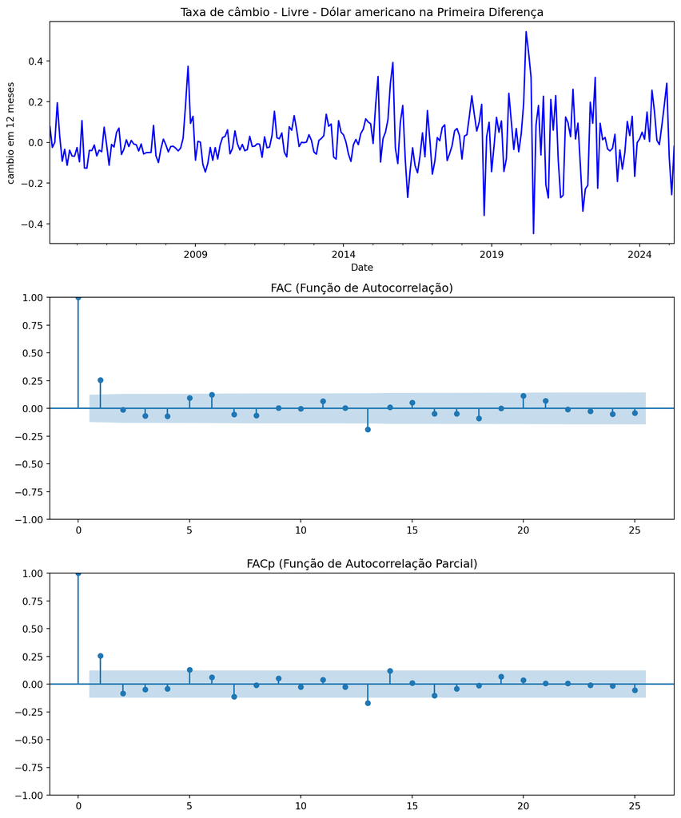

```python
# Criar uma coluna para a primeira diferença da série cambio
cambio['cambio_diff'] = cambio['cambio'].diff()

cambio = cambio.dropna()

# Plota cambio, FAC, e FACpa
fig, axes = plt.subplots(3, 1, figsize=(10, 12))

# Plota cambio
cambio['cambio_diff'].plot(ax=axes[0], title='Taxa de câmbio - Livre - Dólar americano na Primeira Diferença', color='blue')
axes[0].set_ylabel('cambio em 12 meses')

# Plota FAC
plot_acf(cambio['cambio_diff'], ax=axes[1], title='FAC (Função de Autocorrelação)')

# Plota FACp
plot_pacf(cambio['cambio_diff'], ax=axes[2], title='FACp (Função de Autocorrelação Parcial)', method='ywm')

plt.tight_layout()
plt.show()
```

```python
# Executa o teste DF-GLS com seleção automática de defasagens com a série na 1 diferença
dfgls_test_diff = DFGLS(cambio['cambio_diff'], lags=None, trend='c')  # 'ct' para constante + tendência. Apenas c = constante.

# Exibe os resultados
print(dfgls_test_diff.summary())
```

```
      Dickey-Fuller GLS Results
=====================================
Test Statistic                 -2.454
P-value                         0.014
Lags                               13
-------------------------------------

Trend: Constant
Critical Values: -2.65 (1%), -2.03 (5%), -1.71 (10%)
Null Hypothesis: The process contains a unit root.
Alternative Hypothesis: The process is weakly stationary.
```

### Estimação do Modelo ARIMA

```python
#Estimação do modelo ARIMA automatico no Python
#model = auto_arima(
#    cambio['cambio'].dropna(),
#    order=(0, 1, 1),
#    seasonal_order=(0, 0, 1, 12),  # Sazonalidade semanal (12 meses)
#    seasonal=True,
#    trace=True
#)
#print(model.summary())
```

```python
#Estimação do modelo ARIMA automatico no Python
#Forma mais flexivel

model = auto_arima(
    cambio['cambio'].dropna(),
    start_p=0, max_p=6,
    start_q=0, max_q=6,
    d=1,  # já que precisa de uma diferença
    seasonal=True,
    m=12,
    start_P=0, max_P=2,
    start_Q=0, max_Q=2,
    D=0,
    trace=True,
    stepwise=True
)

print(model.summary())
```

```
Performing stepwise search to minimize aic
 ARIMA(0,1,0)(0,0,0)[12] intercept   : AIC=-324.984, Time=0.09 sec
 ARIMA(1,1,0)(1,0,0)[12] intercept   : AIC=-338.647, Time=0.28 sec
 ARIMA(0,1,1)(0,0,1)[12] intercept   : AIC=-340.141, Time=0.38 sec
 ARIMA(0,1,0)(0,0,0)[12]             : AIC=-325.026, Time=0.07 sec
 ARIMA(0,1,1)(0,0,0)[12] intercept   : AIC=-341.522, Time=0.12 sec
 ARIMA(0,1,1)(1,0,0)[12] intercept   : AIC=-340.093, Time=0.30 sec
 ARIMA(0,1,1)(1,0,1)[12] intercept   : AIC=-338.590, Time=0.87 sec
 ARIMA(1,1,1)(0,0,0)[12] intercept   : AIC=-339.534, Time=0.19 sec
 ARIMA(0,1,2)(0,0,0)[12] intercept   : AIC=-339.538, Time=0.26 sec
 ARIMA(1,1,0)(0,0,0)[12] intercept   : AIC=-340.201, Time=0.13 sec
 ARIMA(1,1,2)(0,0,0)[12] intercept   : AIC=-337.523, Time=0.25 sec
 ARIMA(0,1,1)(0,0,0)[12]             : AIC=-342.218, Time=0.10 sec
 ARIMA(0,1,1)(1,0,0)[12]             : AIC=-340.918, Time=0.17 sec
 ARIMA(0,1,1)(0,0,1)[12]             : AIC=-340.968, Time=0.21 sec
 ARIMA(0,1,1)(1,0,1)[12]             : AIC=-339.360, Time=2.00 sec
 ARIMA(1,1,1)(0,0,0)[12]             : AIC=-340.259, Time=0.48 sec
 ARIMA(0,1,2)(0,0,0)[12]             : AIC=-340.267, Time=0.25 sec
 ARIMA(1,1,0)(0,0,0)[12]             : AIC=-341.064, Time=0.08 sec
 ARIMA(1,1,2)(0,0,0)[12]             : AIC=-338.220, Time=0.22 sec

Best model:  ARIMA(0,1,1)(0,0,0)[12]
Total fit time: 6.462 seconds
                               SARIMAX Results
==============================================================================
Dep. Variable:                      y   No. Observations:                  254
Model:               SARIMAX(0, 1, 1)   Log Likelihood                 173.109
Date:                Tue, 15 Apr 2025   AIC                           -342.218
Time:                        15:22:57   BIC                           -335.151
Sample:                    02-01-2004   HQIC                          -339.375
                         - 03-01-2025
Covariance Type:                  opg
==============================================================================
                 coef    std err          z      P>|z|      [0.025      0.975]
------------------------------------------------------------------------------
ma.L1          0.2769      0.041      6.708      0.000       0.196       0.358
sigma2         0.0149      0.001     16.732      0.000       0.013       0.017
===================================================================================
Ljung-Box (L1) (Q):                   0.00   Jarque-Bera (JB):                62.55
Prob(Q):                              0.99   Prob(JB):                         0.00
Heteroskedasticity (H):               5.95   Skew:                             0.06
Prob(H) (two-sided):                  0.00   Kurtosis:                         5.43
===================================================================================

Warnings:
[1] Covariance matrix calculated using the outer product of gradients (complex-step).
```

### Diagnóstico do Modelo

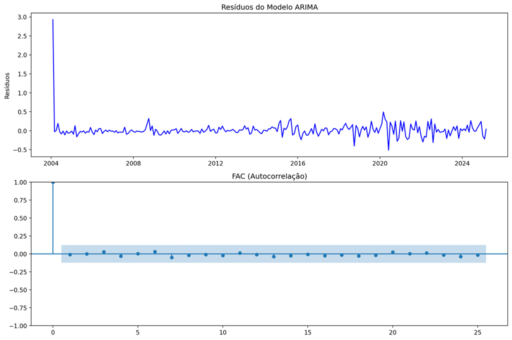

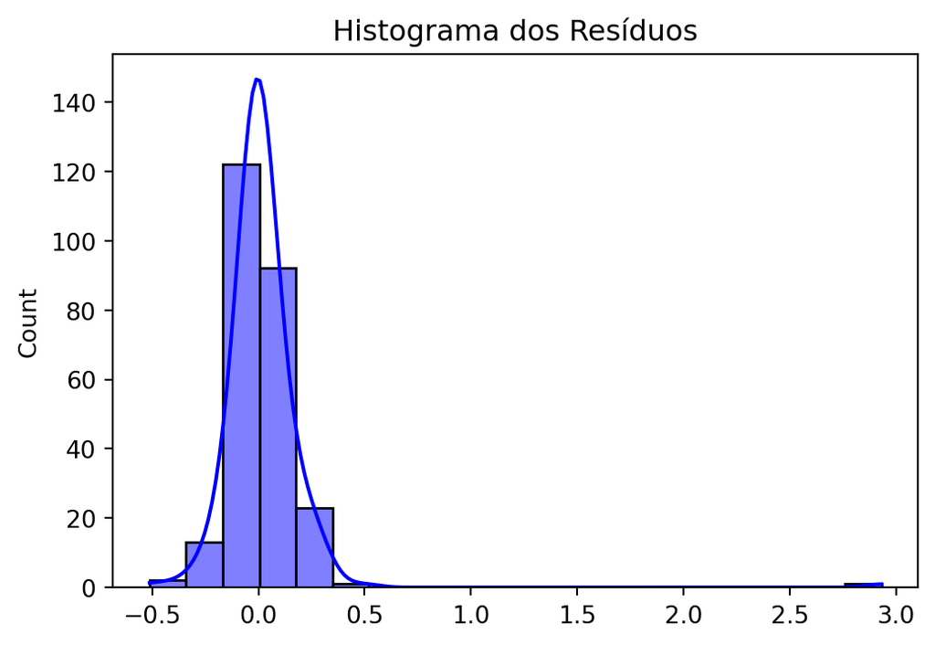

```python
# Obter os resíduos do modelo ARIMA ajustado
residuos = model.resid()

# Criar subplots com layout ajustado para 3 gráficos (2 linhas, 1 coluna)
fig, axes = plt.subplots(2, 1, figsize=(12, 8))

# Gráfico da série dos resíduos
axes[0].plot(residuos, color='blue')
axes[0].set_title('Resíduos do Modelo ARIMA')
axes[0].set_ylabel('Resíduos')

# Gráfico FAC dos resíduos
plot_acf(residuos, ax=axes[1], title='FAC (Autocorrelação)')

plt.tight_layout()
plt.show()

# Histograma dos resíduos em um gráfico separado
plt.figure(figsize=(6, 4))
sns.histplot(residuos, bins=20, kde=True, color='blue')
plt.title('Histograma dos Resíduos')
plt.show()
```

```python
# Teste de Ljung-Box para os resíduos
# Obter os resíduos do modelo ajustado
#residuos2 = pd.Series(model.fit())

# Aplicar o teste de Ljung-Box nos resíduos
ljung_box_test = acorr_ljungbox(residuos, lags=[10, 20, 24], return_df=True)

# Exibir os resultados
print("Teste de Ljung-Box nos Resíduos do auto_arima:")
print(ljung_box_test)
```

```
Teste de Ljung-Box nos Resíduos do auto_arima:
     lb_stat  lb_pvalue
10  1.628866   0.998475
20  2.941044   0.999997
24  3.440290   1.000000
```

```python
#Teste de Normalidade
#from statsmodels.stats.stattools import jarque_bera

jb_test = jarque_bera(residuos)
print(f"Estatística Jarque-Bera: {jb_test[0]}, p-valor: {jb_test[1]}")
```

```
Estatística Jarque-Bera: 152967.81126877439, p-valor: 0.0
```

### Previsão

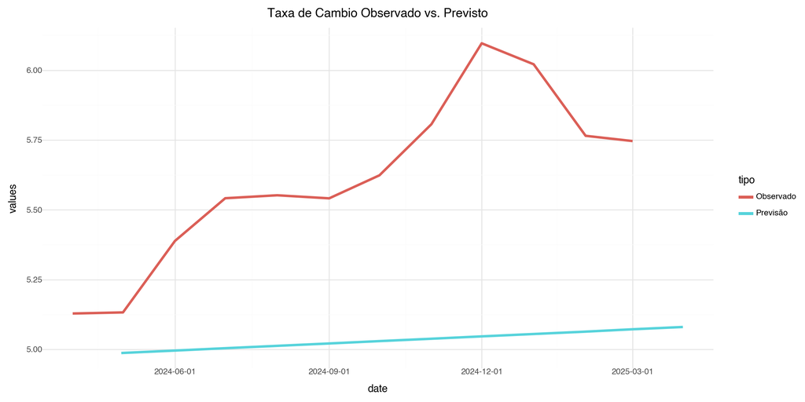

```python
# 1. Separação dos dados em treino e teste
dados_treino = cambio.iloc[:-12]  # Exclui os últimos 12 registros (treino)
dados_teste = cambio.iloc[-12:]    # Últimos 12 registros (teste)

# 2. Estimação do modelo ARIMA(1, 1, 1) com constante
model_arima_treino = ARIMA(dados_treino['cambio'], order=(0, 1, 1), trend='t')
fit_arima_treino = model_arima_treino.fit()

# 3. Previsões para 12 passos à frente
fc_arima = fit_arima_treino.get_forecast(steps=12)
fc_arima_index = pd.date_range(start=dados_teste.index[0], periods=12, freq='ME')

# 4. DataFrame com previsões
fc_arima_df = pd.DataFrame({
    'date': pd.to_datetime(fc_arima_index),
    'values': fc_arima.predicted_mean.astype(float),
    'tipo': 'Previsão'  # Indicar que são previsões
})

# 5. Ajuste do DataFrame de teste
dados_teste_df = dados_teste.copy().reset_index().rename(columns={'Date': 'date'})
dados_teste_df['date'] = pd.to_datetime(dados_teste_df['date'])
dados_teste_df['tipo'] = 'Observado'  # Indicar que são observações
dados_teste_df = dados_teste_df.rename(columns={'cambio': 'values'})
dados_teste_df['values'] = pd.to_numeric(dados_teste_df['values'], errors='coerce')

# 6. União dos DataFrames (observado vs. previsão)
fc_real = pd.concat([dados_teste_df, fc_arima_df])
fc_real['date'] = pd.to_datetime(fc_real['date'])  # Garantir datetime

# 7. Gráfico: Observado vs. Previsto
plot = (
    p9.ggplot(fc_real, p9.aes(x='date', y='values', color='tipo')) +
    p9.geom_line(size=1.5) +
    p9.labs(title="Taxa de Cambio Observado vs. Previsto") +
    p9.theme_minimal() +
    p9.theme(
      figure_size=(12, 6)
    )
)
plot.show()  # Exibir o gráfico
```

### Acurácia

```python
# Calcular as métricas de acurácia
y_true = dados_teste['cambio']
y_pred = fc_arima.predicted_mean

mae = mean_absolute_error(y_true, y_pred)
mse = mean_squared_error(y_true, y_pred)
rmse = np.sqrt(mse)
mape = mean_absolute_percentage_error(y_true, y_pred)

# Exibir os resultados
print(f'MAE: {mae:.4f}')
print(f'MSE: {mse:.4f}')
print(f'RMSE: {rmse:.4f}')
print(f'MAPE: {mape:.4%}')
```

```
MAE: 0.5783
MSE: 0.4048
RMSE: 0.6363
MAPE: 10.0858%
```

### Previsão Fora da Amostra

```
        date  values  cambio_diff       tipo  lower_ci  upper_ci
0 2022-04-01  4.7574      -0.2104  Observado       NaN       NaN
1 2022-05-01  4.9545       0.1971  Observado       NaN       NaN
2 2022-06-01  5.0486       0.0941  Observado       NaN       NaN
3 2022-07-01  5.3675       0.3189  Observado       NaN       NaN
4 2022-08-01  5.1427      -0.2248  Observado       NaN       NaN
```

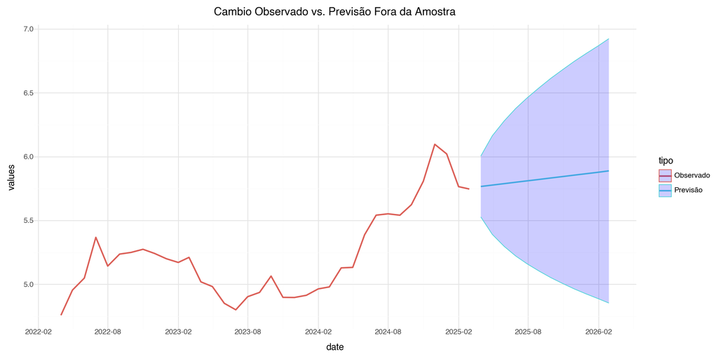

```python
# 1. Reestimar o modelo ARIMA(1, 1, 1) com todos os dados disponíveis
model_arima_full = ARIMA(cambio['cambio'], order=(0, 1, 1), trend='t')
fit_arima_full = model_arima_full.fit()

# 2. Previsões fora da amostra para 12 passos à frente
fc_arima_full = fit_arima_full.get_forecast(steps=12)
fc_arima_full_index = pd.date_range(start=cambio.index[-1], periods=12, freq='ME')

# 3. Criar DataFrame com previsões
fc_arima_full_df = pd.DataFrame({
    'date': pd.to_datetime(fc_arima_full_index),
    'values': fc_arima_full.predicted_mean,
    'lower_ci': fc_arima_full.conf_int().iloc[:, 0],  # Ajuste: pegar a 1ª coluna (lower)
    'upper_ci': fc_arima_full.conf_int().iloc[:, 1],  # Ajuste: pegar a 2ª coluna (upper)
    'tipo': 'Previsão'
})

# 4. Ajustar os dados observados (últimos 36 registros)
dados_observados = cambio.iloc[-36:].copy()
dados_observados = dados_observados.reset_index().rename(columns={'Date': 'date'})  # Ajuste aqui
dados_observados['tipo'] = 'Observado'
dados_observados = dados_observados.rename(columns={'cambio': 'values'})

# ⚠ Adicionar colunas de intervalo com NaN para dados observados
dados_observados['lower_ci'] = np.nan
dados_observados['upper_ci'] = np.nan

#  Garantir que as colunas 'date' sejam datetime
dados_observados['date'] = pd.to_datetime(dados_observados['date'])
fc_arima_full_df['date'] = pd.to_datetime(fc_arima_full_df['date'])

# 5. Combinar previsões e observados
fc_real_full = pd.concat([dados_observados, fc_arima_full_df], ignore_index=True)

# 6. Garantir que a coluna 'date' seja datetime
fc_real_full['date'] = pd.to_datetime(fc_real_full['date'])

print(dados_observados.head())

# 7. Visualizar previsões vs. observado (últimos 36 registros)
plot = (
    p9.ggplot(fc_real_full, p9.aes(x='date', y='values', color='tipo')) +
    p9.geom_line(size=1) +
    p9.geom_ribbon(
        p9.aes(ymin='lower_ci', ymax='upper_ci'),
        data=fc_arima_full_df,
        alpha=0.2,
        fill='blue'
    ) +
    p9.labs(title="Cambio Observado vs. Previsão Fora da Amostra") +
    p9.theme_minimal() +
    p9.theme(
        figure_size=(12, 6),
        legend_position='right'
    ) +
    p9.scale_x_datetime(
        breaks='6 months',
        date_labels='%Y-%m'
    )
)

plot.show()
```